# Comparing Deep Learning Approaches for Glaucoma Detection

## Deep Learning Final Project

Glaucoma is a group of progressive eye diseases characterized by the degeneration of retinal cells and their axons leading to irreversable vision loss. Glaucoma affects over 76 million people globally and has significant challenges to normal detection. A major challenge in glaucoma is that this disease can progress over time silently (or at least minimal symptoms) until vision loss has started to occur. Like most other diseases early detection is critical to slowing disease progression.

Detection of glaucoma involves multimodal assessments combining fundus imaging, tonometry, pachymetry, and visual field testing. However, manual assessment can be subjective and labor intensive which highlights the need for some automated reliable models. Structural changes suggesing disease progression can include cup to disc ratio (CDR) which is a measure of asymmetry between the eyes, neuroretinal rim thinning, peripapillary atrophy or disc hemorrhages etc.

Clinical data as well can be useful in diagnosis highlighting potential irregular values for risk factors. Some typical risk factors include elevated intraocular pressure (IOP), but can also include things such as optic disc cupping, pachymtetry (corneal thickness), axial length of the eye, and visual field mean deivation which comes from visual field testing. These clinical values can come from the imaging themselves or separate risk factors when combined with standard information such as age/gender etc.

Recent advances in machine learning and artificial intelligence have come up with models that look at imaging and have looked at clinical data. However, not much has been done on mixing the 2 approaches to overlay clinical data with the imaging to take a combination approach. Thus, the project here uses 2 different neural networks :

1. A convolutional neural network (CNN) that will analyze the fundus images and extract features
2. A feed forward neural network (FNN) that will process the clinical data

By merging these 2 modalities into a predictive model, we aim to improve diagnostic performance compared to image only or clinical information only approaches. The final model will be assessed on typical machine learning metrics of accuracy, AUC/ROC, and confusion matrix metrics.

The data acquired for this project was taken from the PAPILA dataset which was published in 2022 by Kovalyk et al in Nature Scientific Data (https://www.nature.com/articles/s41597-022-01388-1). The downloaded data was obtained from here : https://figshare.com/articles/dataset/PAPILA/14798004?file=35013982. The specific publication here was a simple ResNet50 image classification task, but our work here will attempt to combine the clinical variables to create a multimodal classification system.

## Step 1 - Loading in the data

Load in the data that was downloaded and do some cleanup.

We will note that there was some imputation that needed to be performed for missing data. In this regard, we choose to take the mean value for the missing data. We could not ignore those data otherwise the sample numbers would be insufficient for a proper model.

We will define the columns once we see the data frame in it's final form below.

```python
import pandas as pd
import os
from glob import glob

# Paths
root_dir = r'C:\Users\derek\Downloads\PAPILA\PAPILA'
fundus_dir = os.path.join(root_dir, 'FundusImages')
clinical_dir = os.path.join(root_dir, 'ClinicalData')
output_metadata_path = os.path.join(root_dir, 'metadata.csv')

# Step 1: Load and clean clinical data
od = pd.read_csv(os.path.join(clinical_dir, 'patient_data_od.txt'), delimiter='\t')
os_ = pd.read_csv(os.path.join(clinical_dir, 'patient_data_os.txt'), delimiter='\t')

# Clean patient IDs: remove '#' only
od['patient_id'] = od.iloc[:, 0].str.replace('#', '')
os_['patient_id'] = os_.iloc[:, 0].str.replace('#', '')

# Drop the original ID column (the first column)
od = od.drop(columns=od.columns[0])
os_ = os_.drop(columns=os_.columns[0])

# Add suffixes to clinical features
od = od.add_suffix('_OD')
os_ = os_.add_suffix('_OS')

# Fix patient_id column names for merging
od = od.rename(columns={'patient_id_OD': 'patient_id'})
os_ = os_.rename(columns={'patient_id_OS': 'patient_id'})

# Merge OD and OS clinical tables
clinical = pd.merge(od, os_, on='patient_id', how='inner')
```

```python
# Step 2: Process fundus images
image_files = glob(os.path.join(fundus_dir, '*.jpg'))

# Build patient_id to image path dictionary
image_dict = {}
for img_path in image_files:
    fname = os.path.basename(img_path)  # Example: RET001OD.jpg
    patient_id = fname[3:6]              # Extract '001', '002', etc.
    eye = fname[6:8]                     # 'OD' or 'OS'

    if patient_id not in image_dict:
        image_dict[patient_id] = {}

    image_dict[patient_id][eye] = img_path

# Convert to DataFrame
image_records = []
for pid, eyes in image_dict.items():
    record = {
        'patient_id': pid,
        'right_eye_image_path': eyes.get('OD', None),
        'left_eye_image_path': eyes.get('OS', None),
    }
    image_records.append(record)

images_df = pd.DataFrame(image_records)
```

```python
# Step 3: Merge clinical and image data
full_data = pd.merge(clinical, images_df, on='patient_id', how='inner')
```

```python
print("Columns in full_data:")
print(full_data.columns.tolist())
```

```
Columns in full_data:
['Age_OD', 'Gender_OD', 'Diagnosis_OD', 'dioptre_1_OD', 'dioptre_2_OD', 'astigmatism_OD', 'Phakic/Pseudophakic_OD', 'Pneumatic_OD', 'Perkins_OD', 'Pachymetry_OD', 'Axial_Length_OD', 'VF_MD_OD', 'patient_id', 'Age_OS', 'Gender_OS', 'Diagnosis_OS', 'dioptre_1_OS', 'dioptre_2_OS', 'astigmatism_OS', 'Ph…
```

```python
# Step 4: Create labels
# Assume diagnosis_OD and diagnosis_OS columns exist
def assign_label(row):
    return int(row['Diagnosis_OD'] == 1 or row['Diagnosis_OS'] == 1)

full_data['label'] = full_data.apply(assign_label, axis=1)
```

```python
# Step 5: Impute missing clinical values (mean imputation)
clinical_features = [col for col in full_data.columns if ('_OD' in col or '_OS' in col) and ('diagnosis' not in col)]

full_data[clinical_features] = full_data[clinical_features].fillna(full_data[clinical_features].mean())
```

```python
# Step 6: Save metadata
final_cols = ['patient_id', 'left_eye_image_path', 'right_eye_image_path'] + clinical_features + ['label']
metadata = full_data[final_cols]

metadata.to_csv(output_metadata_path, index=False)

print(f"Metadata saved to {output_metadata_path}")
print(f"Metadata shape: {metadata.shape}")
print(metadata.head())
```

```
Metadata saved to C:\Users\derek\Downloads\PAPILA\PAPILA\metadata.csv
Metadata shape: (244, 28)
  patient_id                                left_eye_image_path  \
0        002  C:\Users\derek\Downloads\PAPILA\PAPILA\FundusI...
1        004  C:\Users\derek\Downloads\PAPILA\PAPILA\FundusI...
2        005  C:\Users\derek\Downloads\PAPILA\PAPILA\FundusI...
3        006  C:\Users\derek\Downloads\PAPILA\PAPILA\FundusI...
4        007  C:\Users\derek\Downloads\PAPILA\PAPILA\FundusI...

                                right_eye_image_path  Age_OD  Gender_OD  \
0  C:\Users\derek\Downloads\PAPILA\PAPILA\FundusI...      47          0
1  C:\Users\derek\Downloads\PAPILA\PAPILA\FundusI...      58          1
2  C:\Users\derek\Downloads\PAPILA\PAPILA\FundusI...      89          1
3  C:\Users\derek\Downloads\PAPILA\PAPILA\FundusI...      69          0
4  C:\Users\derek\Downloads\PAPILA\PAPILA\FundusI...      22          1

   Diagnosis_OD  dioptre_1_OD  dioptre_2_OD  astigmatism_OD  \
0             2          0.75         -1.75            90.0
1             1          1.50         -1.75            85.0
2             1         -0.75         -1.25           101.0
3             2          1.00         -1.50            95.0
4             2         -0.25          0.00             0.0

   Phakic/Pseudophakic_OD  ...  dioptre_1_OS  dioptre_2_OS  astigmatism_OS  \
0                     0.0  ...         -0.50          -1.5            88.0
1                     0.0  ...          1.50          -2.5            85.0
2                     1.0  ...         -0.50          -2.0           100.0
3                     0.0  ...          1.00          -1.5            85.0
4                     0.0  ...         -0.25          -0.5             0.0

   Phakic/Pseudophakic_OS  Pneumatic_OS  Perkins_OS  Pachymetry_OS  \
0                     0.0     20.000000   17.265625      603.00000
1                     1.0     16.328141   19.000000      511.00000
2                     1.0     24.000000   10.000000      575.00000
3                     0.0     22.000000   17.265625      593.00000
4                     0.0     13.000000   17.265625      535.21097

   Axial_Length_OS  VF_MD_OS  label
0            23.77      0.17      0
1            22.96     -6.77      1
2            24.33     -7.44      1
3            26.21     -3.31      0
4            23.35     -2.61      0

[5 rows x 28 columns]
```

Now that we have the data into data frames let's pause here and make sure that we make sense of what the data columns mean.

First, note there are suffixes on a few of the column names consisting of OS and OD. OD stands for occulus dexter which refers to the right eye, and OS stands for occuls sinister which refers to the left eye. It is possible for glaucoma to develop in one eye first and not the other for many years. This is called unilateral glaucoma and is actually quite common. For this reason we need to make sure that we keep the eye designations and their associated features distinct.

Label in this case we have made as the glaucoma designation. Here I have decided to consider a patient-level approach to the data and consider anyone that has glaucoma symptoms in either eye as a glaucoma patient.

That being said let's define the individual columns :

patient_id : patient ID given in the external data set. They have "#" values in the download which we will need to do some text manipulation on. age : The patient's age

gender : Gender of the patient. 0 = Male, 1 = Female

Diagnosis : Glaucoma diagnosis. 0 = No glaucoma, 1 = glaucoma, 2 = suspected glaucoma. Suspected glaucoma isn't definite and could be problematic in the model.

dioptre : measurement of the eye's refractive power units in diopters (D).

astigmatism : degree of irregular curvature of the cornea or lens.

phakic/pseudophakic : 0 = natural lens present, 1 = artificial introcular lens implanted (after cataract surgery)

pneumatic : Intraocular pressure (IOP) measured during a pneumatic tonometer (air puff test)

perkins : Intraocular pressure (IOP) measured during a perkins applanation tonometer (portable test)

pachymetry : Thickness of the cornea measured in micrometers (um)

axial length : Distance from the front (cornea) to the back (retina) of the eye measured in milimeters (mm).

VF_MD : Visual field mean deviation (mesured in dB).

```python
print(metadata.info())
```

```
<class 'pandas.core.frame.DataFrame'>
RangeIndex: 244 entries, 0 to 243
Data columns (total 28 columns):
 #   Column                  Non-Null Count  Dtype
---  ------                  --------------  -----
 0   patient_id              244 non-null    object
 1   left_eye_image_path     244 non-null    object
 2   right_eye_image_path    244 non-null    object
 3   Age_OD                  244 non-null    int64
 4   Gender_OD               244 non-null    int64
 5   Diagnosis_OD            244 non-null    int64
 6   dioptre_1_OD            244 non-null    float64
 7   dioptre_2_OD            244 non-null    float64
 8   astigmatism_OD          244 non-null    float64
 9   Phakic/Pseudophakic_OD  244 non-null    float64
```

[output cut: 21 more lines]

```python
print(metadata.describe())
```

```
           Age_OD   Gender_OD  Diagnosis_OD  dioptre_1_OD  dioptre_2_OD  \
count  244.000000  244.000000    244.000000    244.000000    244.000000
mean    60.590164    0.618852      0.442623      0.753261     -1.084232
std     13.080161    0.486667      0.726332      1.977299      0.840598
min     15.000000    0.000000      0.000000     -6.500000     -7.500000
25%     52.000000    0.000000      0.000000     -0.250000     -1.500000
50%     62.000000    1.000000      0.000000      0.753261     -1.000000
75%     69.250000    1.000000      1.000000      2.000000     -0.500000
max     90.000000    1.000000      2.000000      6.000000      0.500000

       astigmatism_OD  Phakic/Pseudophakic_OD  Pneumatic_OD  Perkins_OD  \
count      244.000000              244.000000    244.000000  244.000000
mean        89.199170                0.661088     16.190355   17.765625
std         42.024804                0.469428      3.290647    2.074224
min          0.000000                0.000000      9.000000    8.000000
25%         70.000000                0.000000     14.000000   17.765625
50%         90.000000                1.000000     16.190355   17.765625
75%        108.000000                1.000000     18.000000   17.765625
max        180.000000                1.000000     30.000000   29.000000

       Pachymetry_OD  ...  dioptre_1_OS  dioptre_2_OS  astigmatism_OS  \
count     244.000000  ...    244.000000    244.000000      244.000000
mean      538.649789  ...      0.721121     -1.037657       95.920502
std        40.411970  ...      2.179423      0.779525       39.736451
min       432.000000  ...     -8.000000     -4.000000        0.000000
25%       510.750000  ...     -0.250000     -1.500000       78.750000
50%       538.324895  ...      0.750000     -1.000000       90.000000
75%       564.000000  ...      1.750000     -0.500000      111.250000
max       661.000000  ...     11.250000      2.000000      180.000000

       Phakic/Pseudophakic_OS  Pneumatic_OS  Perkins_OS  Pachymetry_OS  \
count              244.000000    244.000000  244.000000     244.000000
mean                 0.673640     16.328141   17.265625     535.210970
std                  0.465006      3.394769    1.782960      40.092765
min                  0.000000      9.000000   10.000000     421.000000
25%                  0.000000     14.000000   17.265625     507.500000
50%                  1.000000     16.328141   17.265625     535.210970
75%                  1.000000     18.000000   17.265625     561.250000
max                  1.000000     29.000000   28.000000     648.000000

       Axial_Length_OS    VF_MD_OS       label
count        244.00000  244.000000  244.000000
mean          23.53300   -4.485732    0.192623
std            1.22414    3.709675    0.395170
min           21.05000  -30.470000    0.000000
25%           22.66000   -4.485732    0.000000
50%           23.40500   -4.485732    0.000000
75%           24.17500   -4.485732    0.000000
max           27.97000    1.550000    1.000000

[8 rows x 25 columns]
```

From this we can see that most of the data is presentable. We are now not missing any data, and the categorical variables are all in place. Naturally some things don't make sense in this describe table such as gender etc., but the data frame is now inputted, we have defined our variables, and we are now ready to start looking at the data.

Before we do, let's put this into a dataset that we can readily share if we want to continue this project later.

```python
# datasets.py

import torch
from torch.utils.data import Dataset
import pandas as pd
from PIL import Image
import torchvision.transforms as transforms

class PAPILADataset(Dataset):
    def __init__(self, csv_file, img_size=224):
        self.data = pd.read_csv(csv_file)

        # Clinical features (all columns except images and label)
        self.clinical_features = [col for col in self.data.columns if ('_OD' in col or '_OS' in col)]

        self.transform = transforms.Compose([
            transforms.Resize((img_size, img_size)),
            transforms.ToTensor(),   # Converts image to [0,1] and CHW format
        ])

    def __len__(self):
        return len(self.data)

    def __getitem__(self, idx):
        row = self.data.iloc[idx]

        # Load left and right eye images
        left_img = Image.open(row['left_eye_image_path']).convert('RGB')
        right_img = Image.open(row['right_eye_image_path']).convert('RGB')

        left_img = self.transform(left_img)
        right_img = self.transform(right_img)

        # Load clinical features
        clinical = torch.tensor(row[self.clinical_features].values, dtype=torch.float32)

        # Load label
        label = torch.tensor(row['label'], dtype=torch.float32)

        return left_img, right_img, clinical, label
```

## Step 2 -> Exploratory Data Analysis

Here we will do some extensive EDA for both the clinical data as well as the images checking for things like class balance, pixel intensities etc.

```
Shape of metadata: (244, 28)
```

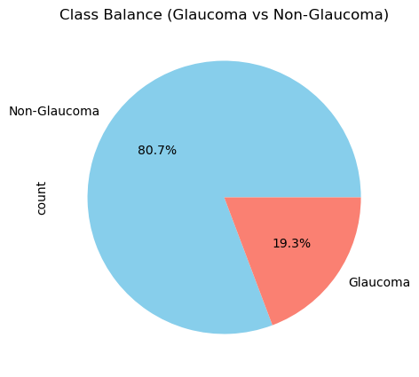

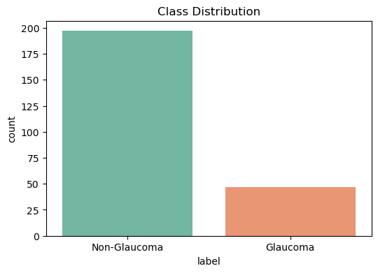

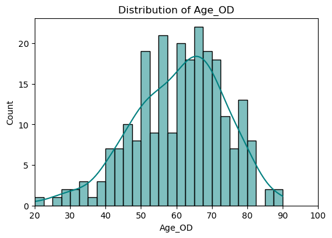

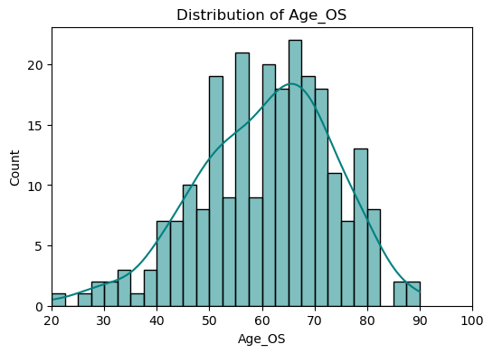

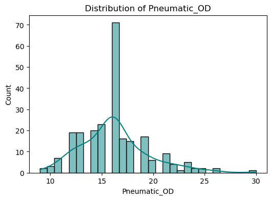

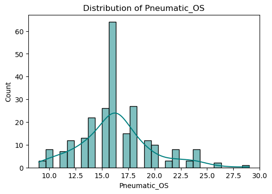

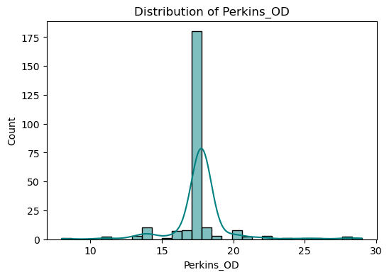

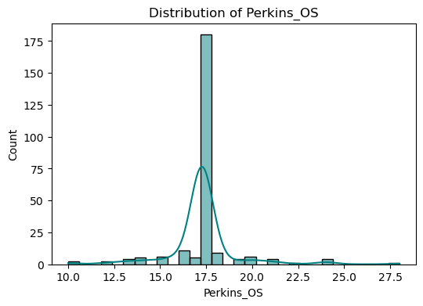

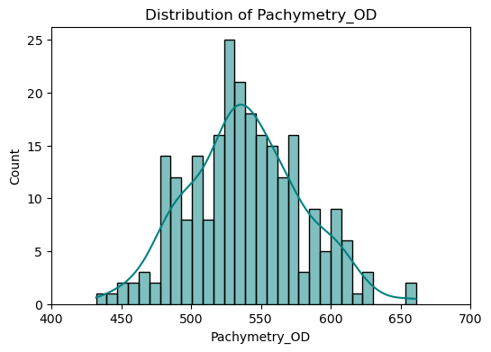

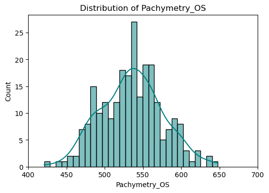

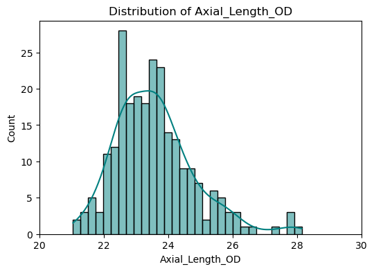

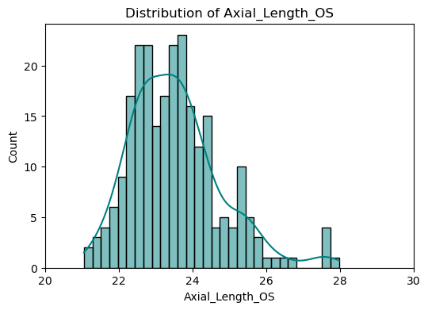

[17 more figures not shown]

```python
# 01_EDA.ipynb

import pandas as pd
import matplotlib.pyplot as plt
import seaborn as sns
from PIL import Image

# Set paths
metadata_path = r'C:\Users\derek\Downloads\PAPILA\PAPILA\metadata.csv'

# Load metadata
df = pd.read_csv(metadata_path)
print(f"Shape of metadata: {df.shape}")

# --- 1. Class balance ---
plt.figure(figsize=(5,5))
df['label'].value_counts().plot(kind='pie', autopct='%1.1f%%', labels=['Non-Glaucoma', 'Glaucoma'], colors=['skyblue', 'salmon'])
plt.title('Class Balance (Glaucoma vs Non-Glaucoma)')
plt.show()

plt.figure(figsize=(6,4))
sns.countplot(x='label', data=df, palette='Set2')
plt.title('Class Distribution')
plt.xticks([0, 1], ['Non-Glaucoma', 'Glaucoma'])
plt.show()

# --- 2. Clinical Features: Histograms and Boxplots ---

clinical_features = [
    'Age_OD', 'Age_OS',
    'Pneumatic_OD', 'Pneumatic_OS',
    'Perkins_OD', 'Perkins_OS',
    'Pachymetry_OD', 'Pachymetry_OS',
    'Axial_Length_OD', 'Axial_Length_OS'
]

# Histograms
for feature in clinical_features:
    plt.figure(figsize=(6,4))
    sns.histplot(df[feature], kde=True, bins=30, color='teal')
    plt.title(f'Distribution of {feature}')
    if 'Age' in feature:
        plt.xlim(20, 100)
    elif 'Pachymetry' in feature:
        plt.xlim(400, 700)
    elif 'Axial_Length' in feature:
        plt.xlim(20, 30)
    plt.xlabel(feature)
    plt.show()

# Boxplots (separated by label)
for feature in clinical_features:
    plt.figure(figsize=(6,4))
    sns.boxplot(x='label', y=feature, data=df, palette='Set3')
    plt.title(f'{feature} by Glaucoma Label')
    plt.xticks([0, 1], ['Non-Glaucoma', 'Glaucoma'])
    plt.show()

# --- 3. Correlation Heatmap ---

# Only numeric columns
corr_features = [col for col in df.columns if ('_OD' in col or '_OS' in col) and ('label' not in col)]
corr_matrix = df[corr_features].corr()

plt.figure(figsize=(14,12))
sns.heatmap(corr_matrix, cmap='coolwarm', center=0, annot=False)
plt.title('Correlation Heatmap of Clinical Features')
plt.show()

# --- 4. Display Sample Fundus Images ---

# Pick 3 normal and 3 glaucoma patients
normal_patients = df[df['label'] == 0].sample(3, random_state=42)
glaucoma_patients = df[df['label'] == 1].sample(3, random_state=42)

def show_patient_images(patient_row, title):
    left_img = Image.open(patient_row['left_eye_image_path'])
    right_img = Image.open(patient_row['right_eye_image_path'])

    fig, axes = plt.subplots(1,2, figsize=(8,4))
    axes[0].imshow(left_img)
    axes[0].set_title('Left Eye')
    axes[0].axis('off')

    axes[1].imshow(right_img)
    axes[1].set_title('Right Eye')
    axes[1].axis('off')

    plt.suptitle(title)
    plt.show()

# Display normal examples
print("Normal Patients:")
for idx, row in normal_patients.iterrows():
    show_patient_images(row, f"Patient ID {row['patient_id']} (Normal)")

# Display glaucoma examples
print("Glaucoma Patients:")
for idx, row in glaucoma_patients.iterrows():
    show_patient_images(row, f"Patient ID {row['patient_id']} (Glaucoma)")
```

There is a lot to unpack here so let's just do some general observations.

First, we have some pretty severe imbalance in the groups. We have many more non-glaucoma patients than those with. This could be problematic later when trying to classify into each group.

Second, the age of the patients in the glaucoma group appear to be significantly higher than those non-glaucoma patients. This isn't a huge surprise sinece glaucoma tends to be more prevalent in the population at later years, but scientificially we would want this to be nearly the same.

Fourth, when comparing the box and whisker plots between glaucoma and non-glaucoma there doesn't appear to be much difference between many of the clinical features. This lends to the central hypothesis that a visual inspection of the fundus images would be more appropriate to make a clinical diagnosis of glaucoma rather than just by clinical features.

Fifth, we performed a simple correlation analysis to show that there isn't much correlation between the values. This makes sense due to the heterogenous nature of the disase and that not all clinical variables will scale the same way. In other words, disease state is different for everyone.

Lastly, we just showed a few of the fundus images such that we can see what we are working with.

### Advanced Fundus Imaging EDA

Let's do some more extensive EDA in the fundus images to check for things like brightness, color contrasting etc.

```
Unique image sizes:
   Height  Width
0     512    512
```

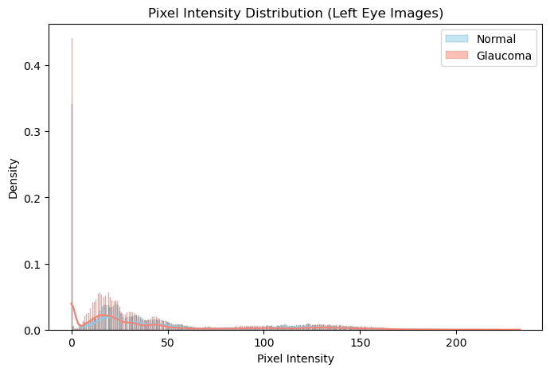

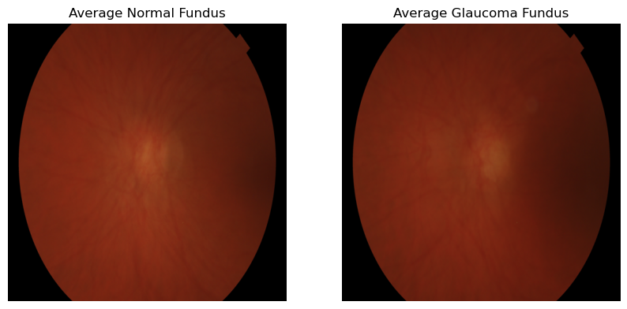

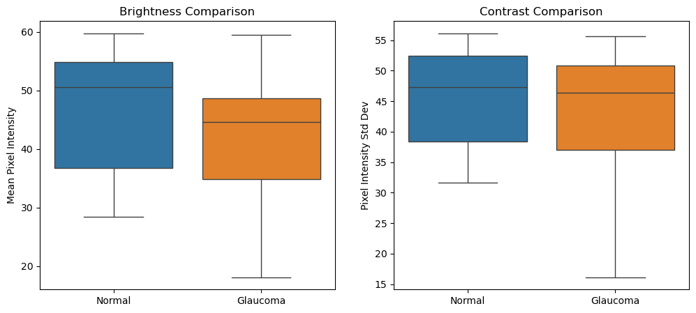

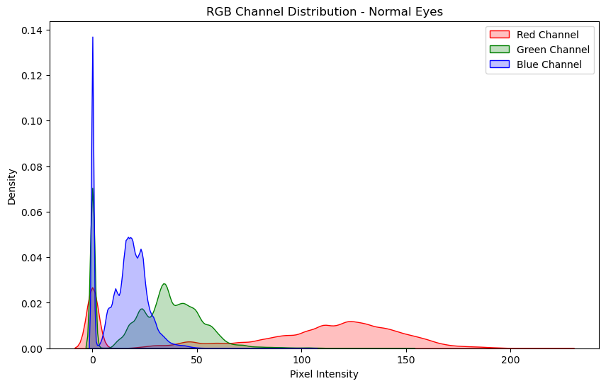

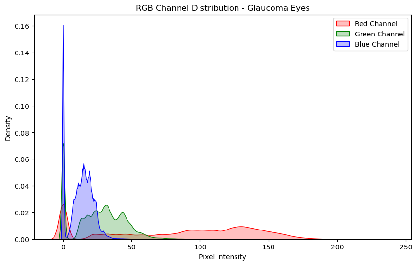

```python
# --- Fundus Image Advanced Analysis ---

import numpy as np

# Helper function to load and process an image
def load_image_as_array(path):
    img = Image.open(path).convert('RGB')
    img = img.resize((512, 512))   # Resize to smaller dimensions
    img = np.array(img)
    return img

# Check image sizes
image_shapes = []

for path in df['left_eye_image_path'].tolist() + df['right_eye_image_path'].tolist():
    img = load_image_as_array(path)
    image_shapes.append(img.shape)

image_shapes = pd.DataFrame(image_shapes, columns=['Height', 'Width', 'Channels'])
print("Unique image sizes:")
print(image_shapes[['Height', 'Width']].drop_duplicates())

# Intensity histograms (normal vs glaucoma)

# Pick 10 random left eye images for each class
normal_pool = df[df['label']==0]['left_eye_image_path']
glaucoma_pool = df[df['label']==1]['left_eye_image_path']

normal_imgs = normal_pool.sample(min(10, len(normal_pool)), random_state=42).tolist()
glaucoma_imgs = glaucoma_pool.sample(min(10, len(glaucoma_pool)), random_state=42).tolist()

normal_pixels = []
glaucoma_pixels = []

for path in normal_imgs:
    img = load_image_as_array(path)
    normal_pixels.append(img.flatten())

for path in glaucoma_imgs:
    img = load_image_as_array(path)
    glaucoma_pixels.append(img.flatten())

normal_pixels = np.concatenate(normal_pixels)
glaucoma_pixels = np.concatenate(glaucoma_pixels)

plt.figure(figsize=(8,5))
sns.histplot(normal_pixels, color='skyblue', label='Normal', kde=True, stat='density')
sns.histplot(glaucoma_pixels, color='salmon', label='Glaucoma', kde=True, stat='density')
plt.legend()
plt.title('Pixel Intensity Distribution (Left Eye Images)')
plt.xlabel('Pixel Intensity')
plt.show()

# Average Fundus Image (Normal vs Glaucoma)

def compute_average_image(paths):
    avg = None
    count = 0
    for path in paths:
        img = load_image_as_array(path).astype(np.float32)
        if avg is None:
            avg = img
        else:
            avg += img
        count += 1
    avg /= count
    return avg.astype(np.uint8)

avg_normal = compute_average_image(normal_imgs)
avg_glaucoma = compute_average_image(glaucoma_imgs)

# Display
fig, axes = plt.subplots(1,2, figsize=(10,5))
axes[0].imshow(avg_normal)
axes[0].set_title('Average Normal Fundus')
axes[0].axis('off')

axes[1].imshow(avg_glaucoma)
axes[1].set_title('Average Glaucoma Fundus')
axes[1].axis('off')

plt.show()

# Brightness and contrast statistics

def compute_brightness_contrast(path_list):
    brightness = []
    contrast = []
    for path in path_list:
        img = load_image_as_array(path).astype(np.float32)
        brightness.append(img.mean())
        contrast.append(img.std())
    return np.array(brightness), np.array(contrast)

brightness_normal, contrast_normal = compute_brightness_contrast(normal_imgs)
brightness_glaucoma, contrast_glaucoma = compute_brightness_contrast(glaucoma_imgs)

# Boxplots
fig, axes = plt.subplots(1,2, figsize=(12,5))

sns.boxplot(data=[brightness_normal, brightness_glaucoma], ax=axes[0])
axes[0].set_xticklabels(['Normal', 'Glaucoma'])
axes[0].set_title('Brightness Comparison')
axes[0].set_ylabel('Mean Pixel Intensity')

sns.boxplot(data=[contrast_normal, contrast_glaucoma], ax=axes[1])
axes[1].set_xticklabels(['Normal', 'Glaucoma'])
axes[1].set_title('Contrast Comparison')
axes[1].set_ylabel('Pixel Intensity Std Dev')

plt.show()

# Color Channel Analysis

def plot_rgb_channels(image_paths, title):
    r_values = []
    g_values = []
    b_values = []

    for path in image_paths:
        img = load_image_as_array(path)
        r_values.append(img[:,:,0].flatten())
        g_values.append(img[:,:,1].flatten())
        b_values.append(img[:,:,2].flatten())

    r_values = np.concatenate(r_values)
    g_values = np.concatenate(g_values)
    b_values = np.concatenate(b_values)

    plt.figure(figsize=(10,6))
    sns.kdeplot(r_values, color='red', label='Red Channel', fill=True)
    sns.kdeplot(g_values, color='green', label='Green Channel', fill=True)
    sns.kdeplot(b_values, color='blue', label='Blue Channel', fill=True)
    plt.title(title)
    plt.xlabel('Pixel Intensity')
    plt.legend()
    plt.show()

plot_rgb_channels(normal_imgs, "RGB Channel Distribution - Normal Eyes")
plot_rgb_channels(glaucoma_imgs, "RGB Channel Distribution - Glaucoma Eyes")
```

Here we downsize the images to 512x512. The initial images are 1423x2132, but we do not need this level of detail. Some notes from the graphs :

First, the pixel intensity distribution shows that there is a spike of density at 0. This represents a black color and as you can see from the image itself there is quite a bit of darkness and blackspace around the eye itself. This lends to that density being overdone.

Second, there isn't much diffrence between brightness and contrast comparisons between the glaucoma and normal eye images. This is very good since our model will not need to be color normalized.

Lastly, The RGB color distribution shows a bit of difference between glaucoma and normal eye, but it doesn't rise to the level of concern. The graph shows that indeed the color distributions reflect dark images, but otherwise it's pretty much the same.

## Model that only looks at clinical data and nothing else.

The first model we want to implement is a model that only looks at the clinical data and ignores the fundus images.

We have developed a very simple and shallow feedforward neural network (multilayer perceptron) with an input layer, 2 hidden layers with ReLU activation, and an output layer.

The simplicity of the model is valid here since we are only working with a handful of clinical variables and is perfect for structured tabular data. Additionally, there is a very low risk of overfitting with such a model. Additional benefits include, speed of training and scalability to additional features later if necessary.

Also, it pairs well with pytorch BCE loss function since it outputs a logit value per patient.

So let's now go on with defining and running the model.

```python
class ClinicalOnlyGlaucomaModel(nn.Module):
    def __init__(self, num_clinical_features):
        super(ClinicalOnlyGlaucomaModel, self).__init__()

        self.mlp = nn.Sequential(
            nn.Linear(num_clinical_features, 128),
            nn.ReLU(),
            nn.Linear(128, 64),
            nn.ReLU(),
            nn.Linear(64, 1)   # No Sigmoid
        )

    def forward(self, clinical_data):
        output = self.mlp(clinical_data)  # (batch_size, 1)
        return output
```

```python
from torch.utils.data import Dataset, DataLoader, random_split
import torch.optim as optim


class ClinicalDataset(Dataset):
    def __init__(self, csv_file):
        self.data = pd.read_csv(csv_file)
        self.clinical_features = [col for col in self.data.columns if ('_OD' in col or '_OS' in col)]

    def __len__(self):
        return len(self.data)

    def __getitem__(self, idx):
        row = self.data.iloc[idx]

        # Force all clinical feature values to float32
        clinical_values = row[self.clinical_features].astype(np.float32).values

        clinical = torch.tensor(clinical_values, dtype=torch.float32)
        label = torch.tensor(row['label'], dtype=torch.float32)

        return clinical, label

# Path to your metadata
csv_file = r'C:\Users\derek\Downloads\PAPILA\PAPILA\metadata.csv'

# Parameters
num_epochs = 20
batch_size = 16
learning_rate = 1e-3
train_val_split = 0.8
device = torch.device('cuda' if torch.cuda.is_available() else 'cpu')

# Load dataset
full_dataset = ClinicalDataset(csv_file)
train_size = int(train_val_split * len(full_dataset))
val_size = len(full_dataset) - train_size

train_dataset, val_dataset = random_split(full_dataset, [train_size, val_size])

train_loader = DataLoader(train_dataset, batch_size=batch_size, shuffle=True)
val_loader = DataLoader(val_dataset, batch_size=batch_size, shuffle=False)

# Initialize model
num_clinical_features = len(full_dataset.clinical_features)
model = ClinicalOnlyGlaucomaModel(num_clinical_features=num_clinical_features).to(device)

# Loss and optimizer
criterion = nn.BCEWithLogitsLoss()
optimizer = optim.Adam(model.parameters(), lr=learning_rate)
```

```python
from sklearn.metrics import roc_auc_score, accuracy_score

train_losses = []
val_losses = []
val_accuracies = []
val_aucs = []

for epoch in range(num_epochs):
    model.train()
    running_loss = 0.0
    for clinical_data, labels in train_loader:
        clinical_data = clinical_data.to(device)
        labels = labels.to(device)
        labels = labels.unsqueeze(1)  # Make labels (batch_size, 1)

        optimizer.zero_grad()
        outputs = model(clinical_data)  # outputs shape (batch_size, 1)

        loss = criterion(outputs, labels)
        loss.backward()
        optimizer.step()

        running_loss += loss.item()

    avg_train_loss = running_loss / len(train_loader)
    train_losses.append(avg_train_loss)

    # Validation phase
    model.eval()
    val_loss = 0.0
    all_labels = []
    all_preds = []
    with torch.no_grad():
        for clinical_data, labels in val_loader:
            clinical_data = clinical_data.to(device)
            labels = labels.to(device)
            labels = labels.unsqueeze(1)  # Again make labels (batch_size, 1)

            outputs = model(clinical_data)
            loss = criterion(outputs, labels)
            val_loss += loss.item()

            preds = torch.sigmoid(outputs)  # Since model outputs raw logits
            preds = preds.detach().cpu().numpy()
            labels = labels.detach().cpu().numpy()

            all_labels.extend(labels.flatten())
            all_preds.extend(preds.flatten())

    avg_val_loss = val_loss / len(val_loader)
    val_losses.append(avg_val_loss)

    val_acc = accuracy_score(np.round(all_labels), np.round(all_preds))
    val_auc = roc_auc_score(all_labels, all_preds)

    val_accuracies.append(val_acc)
    val_aucs.append(val_auc)

    print(f"Epoch [{epoch+1}/{num_epochs}] "
          f"Train Loss: {avg_train_loss:.4f} "
          f"Val Loss: {avg_val_loss:.4f} "
          f"Val Acc: {val_acc:.4f} "
          f"Val AUC: {val_auc:.4f}")
```

```
Epoch [1/20] Train Loss: 5.5696 Val Loss: 0.5016 Val Acc: 0.7959 Val AUC: 0.6769
Epoch [2/20] Train Loss: 1.0779 Val Loss: 2.0463 Val Acc: 0.2041 Val AUC: 0.6974
Epoch [3/20] Train Loss: 1.1823 Val Loss: 0.5597 Val Acc: 0.7347 Val AUC: 0.7667
Epoch [4/20] Train Loss: 0.6846 Val Loss: 0.5103 Val Acc: 0.7959 Val AUC: 0.7718
Epoch [5/20] Train Loss: 0.5493 Val Loss: 0.4210 Val Acc: 0.8163 Val AUC: 0.8000
Epoch [6/20] Train Loss: 0.5495 Val Loss: 0.5027 Val Acc: 0.7959 Val AUC: 0.7744
Epoch [7/20] Train Loss: 0.4724 Val Loss: 0.7169 Val Acc: 0.5918 Val AUC: 0.7872
Epoch [8/20] Train Loss: 0.4791 Val Loss: 0.3870 Val Acc: 0.8163 Val AUC: 0.8205
Epoch [9/20] Train Loss: 0.4243 Val Loss: 0.4074 Val Acc: 0.8571 Val AUC: 0.8000
Epoch [10/20] Train Loss: 0.3916 Val Loss: 0.3769 Val Acc: 0.8163 Val AUC: 0.8026
Epoch [11/20] Train Loss: 0.4320 Val Loss: 0.4076 Val Acc: 0.8163 Val AUC: 0.7897
Epoch [12/20] Train Loss: 0.6166 Val Loss: 0.5132 Val Acc: 0.8163 Val AUC: 0.7667
Epoch [13/20] Train Loss: 0.5075 Val Loss: 0.4967 Val Acc: 0.7755 Val AUC: 0.8000
Epoch [14/20] Train Loss: 0.4045 Val Loss: 0.9414 Val Acc: 0.4898 Val AUC: 0.7846
Epoch [15/20] Train Loss: 0.5432 Val Loss: 0.3955 Val Acc: 0.8163 Val AUC: 0.8077
Epoch [16/20] Train Loss: 0.5099 Val Loss: 0.4315 Val Acc: 0.8163 Val AUC: 0.8231
Epoch [17/20] Train Loss: 0.5032 Val Loss: 0.8859 Val Acc: 0.5510 Val AUC: 0.8410
Epoch [18/20] Train Loss: 0.4414 Val Loss: 0.3924 Val Acc: 0.8571 Val AUC: 0.8128
Epoch [19/20] Train Loss: 0.4242 Val Loss: 0.5990 Val Acc: 0.7551 Val AUC: 0.8077
Epoch [20/20] Train Loss: 0.4891 Val Loss: 0.3720 Val Acc: 0.8571 Val AUC: 0.8436
```

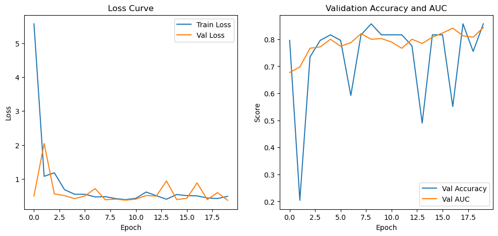

```python
plt.figure(figsize=(12,5))
plt.subplot(1,2,1)
plt.plot(train_losses, label='Train Loss')
plt.plot(val_losses, label='Val Loss')
plt.title('Loss Curve')
plt.xlabel('Epoch')
plt.ylabel('Loss')
plt.legend()

plt.subplot(1,2,2)
plt.plot(val_accuracies, label='Val Accuracy')
plt.plot(val_aucs, label='Val AUC')
plt.title('Validation Accuracy and AUC')
plt.xlabel('Epoch')
plt.ylabel('Score')
plt.legend()

plt.show()
```

```
Validation Accuracy: 0.8571
Validation Precision: 1.0000
Validation Recall: 0.3000
Validation F1 Score: 0.4615
Validation ROC AUC: 0.8436

Confusion Matrix:
[[39  0]
 [ 7  3]]
```

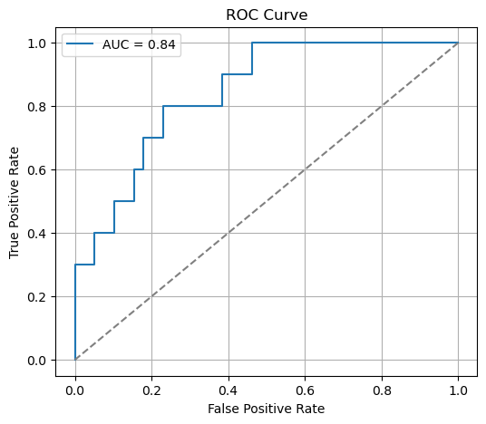

```python
from sklearn.metrics import precision_score, recall_score, f1_score, confusion_matrix, roc_curve

# Re-evaluate model comprehensively
model.eval()
all_labels = []
all_preds = []

with torch.no_grad():
    for clinical_data, labels in val_loader:
        clinical_data = clinical_data.to(device)
        labels = labels.to(device)
        labels = labels.unsqueeze(1)

        outputs = model(clinical_data)
        preds = torch.sigmoid(outputs)

        preds = preds.detach().cpu().numpy()
        labels = labels.detach().cpu().numpy()

        all_labels.extend(labels.flatten())
        all_preds.extend(preds.flatten())

# Convert to numpy arrays
all_labels = np.array(all_labels)
all_preds = np.array(all_preds)

# Binary predictions
binary_preds = np.round(all_preds)

# Compute Metrics
acc = accuracy_score(all_labels, binary_preds)
precision = precision_score(all_labels, binary_preds)
recall = recall_score(all_labels, binary_preds)
f1 = f1_score(all_labels, binary_preds)
auc = roc_auc_score(all_labels, all_preds)
cm = confusion_matrix(all_labels, binary_preds)

print(f"Validation Accuracy: {acc:.4f}")
print(f"Validation Precision: {precision:.4f}")
print(f"Validation Recall: {recall:.4f}")
print(f"Validation F1 Score: {f1:.4f}")
print(f"Validation ROC AUC: {auc:.4f}")

print("\nConfusion Matrix:")
print(cm)

# ROC Curve
fpr, tpr, thresholds = roc_curve(all_labels, all_preds)
plt.figure(figsize=(6,5))
plt.plot(fpr, tpr, label=f'AUC = {auc:.2f}')
plt.plot([0, 1], [0, 1], '--', color='gray')
plt.xlabel('False Positive Rate')
plt.ylabel('True Positive Rate')
plt.title('ROC Curve')
plt.legend()
plt.grid()
plt.show()
```

After implementing and running the clinical only model let's make a few observations. First, the ROC is pretty respectable with an AUC at 0.84. This shows that there is some pretty good clinical features here that define glaucoma. However, since we don't have a ton of data here it's pretty hard to gauge the actual validity of the model. This is reflective of that very ugly loss curve during training. Ho boy is that bad.

### Fundus Imaging ONLY analysis

Now that we have a proper baseline for the clinical data, let's get a baseline for a model that only looks at the images.

The reason why I've selected Resnet18 is that it is widely used in opthamaology classification tasks with retinal, optic and fundus imaging in other studies and performs very well on smaller datasets. Staring with the ImageNet pretrained weights will help with the transfer learning for low-level features such as edges and textures which is useful since we have only a couple hundred patients. Additionally, the Resnet18 architecture is that it is efficient and fast even on CPU (which is all I have right now to work on).

The classifier node is linear (1024->128) and combines fused features from both eyes. A ReLU is used for non-linearity and a linear output is used for (128 -> 1) such that the final output is logit.

Now that the definitions have been done, let's implement the Resnet18 architecture and perform model fitting and evaluation.

```python
class FundusDataset(Dataset):
    def __init__(self, csv_file, img_size=224):
        self.data = pd.read_csv(csv_file)
        self.transform = transforms.Compose([
            transforms.Resize((img_size, img_size)),
            transforms.ToTensor(),
            transforms.Normalize([0.5], [0.5])  # Simple normalization
        ])

    def __len__(self):
        return len(self.data)

    def __getitem__(self, idx):
        row = self.data.iloc[idx]

        left_img = Image.open(row['left_eye_image_path']).convert('RGB')
        right_img = Image.open(row['right_eye_image_path']).convert('RGB')

        left_img = self.transform(left_img)
        right_img = self.transform(right_img)

        label = torch.tensor(row['label'], dtype=torch.float32)

        return left_img, right_img, label
```

```python
import torchvision.models as models
import torchvision.transforms as transforms
from PIL import Image

# Path to your metadata
csv_file = r'C:\Users\derek\Downloads\PAPILA\PAPILA\metadata.csv'

# Hyperparameters
num_epochs = 20
batch_size = 16
learning_rate = 1e-4
train_val_split = 0.8
device = torch.device('cuda' if torch.cuda.is_available() else 'cpu')

# Dataset and DataLoader
full_dataset = FundusDataset(csv_file)
train_size = int(train_val_split * len(full_dataset))
val_size = len(full_dataset) - train_size

train_dataset, val_dataset = random_split(full_dataset, [train_size, val_size])

train_loader = DataLoader(train_dataset, batch_size=batch_size, shuffle=True)
val_loader = DataLoader(val_dataset, batch_size=batch_size, shuffle=False)

# Model, Loss, Optimizer
model = FundusOnlyGlaucomaModel(pretrained=True).to(device)
criterion = nn.BCEWithLogitsLoss()
optimizer = optim.Adam(model.parameters(), lr=learning_rate)
```

```python
import torch
import torch.nn as nn
import torch.optim as optim
from torch.utils.data import Dataset, DataLoader, random_split
from torchvision import models, transforms
from PIL import Image
import pandas as pd
import numpy as np
import matplotlib.pyplot as plt
from sklearn.metrics import accuracy_score, roc_auc_score, precision_score, recall_score, f1_score, confusion_matrix, roc_curve

class FundusDataset(Dataset):
    def __init__(self, csv_file, img_size=224):
        self.data = pd.read_csv(csv_file)
        self.transform = transforms.Compose([
            transforms.Resize((img_size, img_size)),
            transforms.ToTensor(),
            transforms.Normalize([0.5], [0.5])  # Simple normalization
        ])

    def __len__(self):
        return len(self.data)

    def __getitem__(self, idx):
        row = self.data.iloc[idx]

        left_img = Image.open(row['left_eye_image_path']).convert('RGB')
        right_img = Image.open(row['right_eye_image_path']).convert('RGB')

        left_img = self.transform(left_img)
        right_img = self.transform(right_img)

        label = torch.tensor(row['label'], dtype=torch.float32)

        return left_img, right_img, label

class FundusDataset(Dataset):
    def __init__(self, csv_file, img_size=224):
        self.data = pd.read_csv(csv_file)
        self.transform = transforms.Compose([
            transforms.Resize((img_size, img_size)),
            transforms.ToTensor(),
            transforms.Normalize([0.5], [0.5])  # Simple normalization
        ])

    def __len__(self):
        return len(self.data)

    def __getitem__(self, idx):
        row = self.data.iloc[idx]

        left_img = Image.open(row['left_eye_image_path']).convert('RGB')
        right_img = Image.open(row['right_eye_image_path']).convert('RGB')

        left_img = self.transform(left_img)
        right_img = self.transform(right_img)

        label = torch.tensor(row['label'], dtype=torch.float32)

        return left_img, right_img, label

class FundusOnlyGlaucomaModel(nn.Module):
    def __init__(self, pretrained=True):
        super(FundusOnlyGlaucomaModel, self).__init__()

        base_cnn = models.resnet18(pretrained=pretrained)
        self.cnn_encoder = nn.Sequential(*list(base_cnn.children())[:-1])  # Remove final FC

        cnn_output_size = base_cnn.fc.in_features  # 512

        self.classifier = nn.Sequential(
            nn.Linear(cnn_output_size * 2, 128),
            nn.ReLU(),
            nn.Linear(128, 1)  # 1 output neuron (raw logits)
        )

    def forward(self, left_img, right_img):
        left_feat = self.cnn_encoder(left_img).flatten(1)
        right_feat = self.cnn_encoder(right_img).flatten(1)

        fused = torch.cat([left_feat, right_feat], dim=1)  # (batch_size, 1024)
        output = self.classifier(fused)  # (batch_size, 1)
        return output

csv_file = r'C:\Users\derek\Downloads\PAPILA\PAPILA\metadata.csv'  # your path

num_epochs = 20
batch_size = 16
learning_rate = 1e-4
train_val_split = 0.8
device = torch.device('cuda' if torch.cuda.is_available() else 'cpu')

full_dataset = FundusDataset(csv_file)
train_size = int(train_val_split * len(full_dataset))
val_size = len(full_dataset) - train_size

train_dataset, val_dataset = random_split(full_dataset, [train_size, val_size])

train_loader = DataLoader(train_dataset, batch_size=batch_size, shuffle=True)
val_loader = DataLoader(val_dataset, batch_size=batch_size, shuffle=False)

model = FundusOnlyGlaucomaModel(pretrained=True).to(device)
criterion = nn.BCEWithLogitsLoss()
optimizer = optim.Adam(model.parameters(), lr=learning_rate)

train_losses = []
val_losses = []
val_accuracies = []
val_aucs = []

for epoch in range(num_epochs):
    model.train()
    running_loss = 0.0

    for left_img, right_img, labels in train_loader:
        left_img = left_img.to(device)
        right_img = right_img.to(device)
        labels = labels.to(device)
        labels = labels.unsqueeze(1)  # (batch_size, 1)

        optimizer.zero_grad()
        outputs = model(left_img, right_img)

        loss = criterion(outputs, labels)
        loss.backward()
        optimizer.step()

        running_loss += loss.item()

    avg_train_loss = running_loss / len(train_loader)
    train_losses.append(avg_train_loss)

    # Validation
    model.eval()
    val_loss = 0.0
    all_labels = []
    all_preds = []

    with torch.no_grad():
        for left_img, right_img, labels in val_loader:
            left_img = left_img.to(device)
            right_img = right_img.to(device)
            labels = labels.to(device)
            labels = labels.unsqueeze(1)

            outputs = model(left_img, right_img)
            loss = criterion(outputs, labels)
            val_loss += loss.item()

            preds = torch.sigmoid(outputs)
            preds = preds.detach().cpu().numpy()
            labels = labels.detach().cpu().numpy()

            all_labels.extend(labels.flatten())
            all_preds.extend(preds.flatten())

    avg_val_loss = val_loss / len(val_loader)
    val_losses.append(avg_val_loss)

    val_acc = accuracy_score(np.round(all_labels), np.round(all_preds))
    val_auc = roc_auc_score(all_labels, all_preds)

    val_accuracies.append(val_acc)
    val_aucs.append(val_auc)

    print(f"Epoch [{epoch+1}/{num_epochs}] "
          f"Train Loss: {avg_train_loss:.4f} "
          f"Val Loss: {avg_val_loss:.4f} "
          f"Val Acc: {val_acc:.4f} "
          f"Val AUC: {val_auc:.4f}")
```

```
Epoch [1/20] Train Loss: 0.5008 Val Loss: 0.3327 Val Acc: 0.8163 Val AUC: 0.8750
Epoch [2/20] Train Loss: 0.2725 Val Loss: 0.2963 Val Acc: 0.8367 Val AUC: 0.8944
Epoch [3/20] Train Loss: 0.1239 Val Loss: 0.3103 Val Acc: 0.8367 Val AUC: 0.8750
Epoch [4/20] Train Loss: 0.0547 Val Loss: 0.3337 Val Acc: 0.8776 Val AUC: 0.8222
Epoch [5/20] Train Loss: 0.0239 Val Loss: 0.3070 Val Acc: 0.8571 Val AUC: 0.8722
Epoch [6/20] Train Loss: 0.0146 Val Loss: 0.4002 Val Acc: 0.8571 Val AUC: 0.8472
Epoch [7/20] Train Loss: 0.0240 Val Loss: 0.3047 Val Acc: 0.8776 Val AUC: 0.8972
Epoch [8/20] Train Loss: 0.0212 Val Loss: 0.4467 Val Acc: 0.8163 Val AUC: 0.8139
Epoch [9/20] Train Loss: 0.0085 Val Loss: 0.4220 Val Acc: 0.8367 Val AUC: 0.8750
Epoch [10/20] Train Loss: 0.0067 Val Loss: 0.4272 Val Acc: 0.8776 Val AUC: 0.8333
Epoch [11/20] Train Loss: 0.0288 Val Loss: 0.4304 Val Acc: 0.8367 Val AUC: 0.7694
Epoch [12/20] Train Loss: 0.0179 Val Loss: 0.2286 Val Acc: 0.8776 Val AUC: 0.9389
Epoch [13/20] Train Loss: 0.0312 Val Loss: 0.3990 Val Acc: 0.8367 Val AUC: 0.9417
Epoch [14/20] Train Loss: 0.0158 Val Loss: 0.2967 Val Acc: 0.8163 Val AUC: 0.9111
Epoch [15/20] Train Loss: 0.0310 Val Loss: 0.2733 Val Acc: 0.7959 Val AUC: 0.9306
Epoch [16/20] Train Loss: 0.0410 Val Loss: 0.2857 Val Acc: 0.8980 Val AUC: 0.9472
Epoch [17/20] Train Loss: 0.0389 Val Loss: 0.2639 Val Acc: 0.8980 Val AUC: 0.9417
Epoch [18/20] Train Loss: 0.0327 Val Loss: 0.3014 Val Acc: 0.8571 Val AUC: 0.9333
Epoch [19/20] Train Loss: 0.0164 Val Loss: 0.2759 Val Acc: 0.8571 Val AUC: 0.9250
Epoch [20/20] Train Loss: 0.0061 Val Loss: 0.3276 Val Acc: 0.8367 Val AUC: 0.9389
```

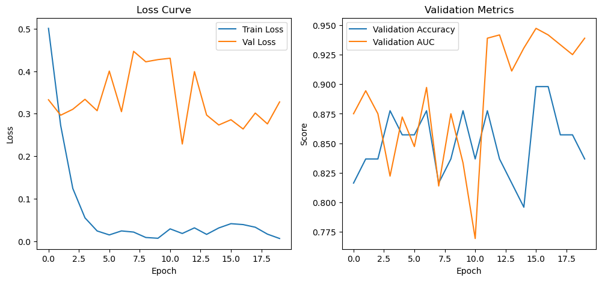

```python
plt.figure(figsize=(12,5))
plt.subplot(1,2,1)
plt.plot(train_losses, label='Train Loss')
plt.plot(val_losses, label='Val Loss')
plt.title('Loss Curve')
plt.xlabel('Epoch')
plt.ylabel('Loss')
plt.legend()

plt.subplot(1,2,2)
plt.plot(val_accuracies, label='Validation Accuracy')
plt.plot(val_aucs, label='Validation AUC')
plt.title('Validation Metrics')
plt.xlabel('Epoch')
plt.ylabel('Score')
plt.legend()

plt.show()
```

```
Final Validation Metrics:
Accuracy: 0.8367
Precision: 0.6667
Recall: 0.2222
F1 Score: 0.3333
ROC AUC: 0.9389
Confusion Matrix:
[[39  1]
 [ 7  2]]
```

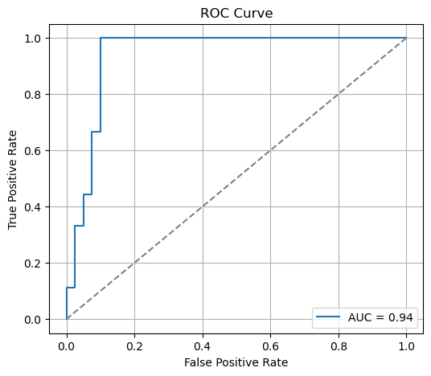

```python
model.eval()
all_labels = []
all_preds = []

with torch.no_grad():
    for left_img, right_img, labels in val_loader:
        left_img = left_img.to(device)
        right_img = right_img.to(device)
        labels = labels.to(device)
        labels = labels.unsqueeze(1)

        outputs = model(left_img, right_img)
        preds = torch.sigmoid(outputs)

        preds = preds.detach().cpu().numpy()
        labels = labels.detach().cpu().numpy()

        all_labels.extend(labels.flatten())
        all_preds.extend(preds.flatten())

all_labels = np.array(all_labels)
all_preds = np.array(all_preds)
binary_preds = np.round(all_preds)

acc = accuracy_score(all_labels, binary_preds)
precision = precision_score(all_labels, binary_preds)
recall = recall_score(all_labels, binary_preds)
f1 = f1_score(all_labels, binary_preds)
auc = roc_auc_score(all_labels, all_preds)
cm = confusion_matrix(all_labels, binary_preds)

print(f"\nFinal Validation Metrics:")
print(f"Accuracy: {acc:.4f}")
print(f"Precision: {precision:.4f}")
print(f"Recall: {recall:.4f}")
print(f"F1 Score: {f1:.4f}")
print(f"ROC AUC: {auc:.4f}")
print(f"Confusion Matrix:\n{cm}")

# ROC curve
fpr, tpr, thresholds = roc_curve(all_labels, all_preds)
plt.figure(figsize=(6,5))
plt.plot(fpr, tpr, label=f'AUC = {auc:.2f}')
plt.plot([0, 1], [0, 1], '--', color='gray')
plt.xlabel('False Positive Rate')
plt.ylabel('True Positive Rate')
plt.title('ROC Curve')
plt.legend()
plt.grid()
plt.show()
```

### Multimodal model

Finally, let's look at the multimodal data with the clinical data and the imaging data combined into a single model.

Here I have implemented a dual branch deep neural network which fuses the CNN model from the imaging analysis with the MLP of the clinical data model. The CNN branch takes the 2 fundus images and pass it through a shared ResNet18 encoder and outputs a 512D feature per eye (or 1024D total). The clinical feature branch uses the MLP with 2 layers and a ReLU activation outputting a 64D vector. The fusion layer here concatenates the 1024D vector and the 64D clinical vector into a 1088D fused feature. This feature encapsulates a single patient, but has the characteristics of both the fundus image as well as the clinical diagnostics. The classifier head here is a fully connected layers that moves from 1088 -> 128 -> 1 and outputs a binar classification using BCEWithLogitsLoss.

The goal of this model is to mimic clinical decision making by using multiple decision points including fundus imaging and patient history. The fusion model is simple yet effective which just a simple concatenation of the dimensions which represents the merging of imaging and clinical features into a per patient feature set. This can then be shared for further analysis very easily. Each of the models can be extended or replaced at this level very easily for future extension or modification.

So that being said let's create the multimodal model.

```python
class MultimodalDataset(Dataset):
    def __init__(self, csv_file, img_size=224):
        self.data = pd.read_csv(csv_file)
        self.clinical_features = [col for col in self.data.columns if ('_OD' in col or '_OS' in col)]
        self.transform = transforms.Compose([
            transforms.Resize((img_size, img_size)),
            transforms.ToTensor(),
            transforms.Normalize([0.5], [0.5])
        ])

    def __len__(self):
        return len(self.data)

    def __getitem__(self, idx):
        row = self.data.iloc[idx]

        left_img = Image.open(row['left_eye_image_path']).convert('RGB')
        right_img = Image.open(row['right_eye_image_path']).convert('RGB')

        left_img = self.transform(left_img)
        right_img = self.transform(right_img)

        clinical = torch.tensor(row[self.clinical_features].astype(np.float32).values, dtype=torch.float32)
        label = torch.tensor(row['label'], dtype=torch.float32)

        return left_img, right_img, clinical, label

class MultimodalGlaucomaModel(nn.Module):
    def __init__(self, num_clinical_features, pretrained=True):
        super(MultimodalGlaucomaModel, self).__init__()

        # CNN for fundus images
        base_cnn = models.resnet18(pretrained=pretrained)
        self.cnn_encoder = nn.Sequential(*list(base_cnn.children())[:-1])  # Remove last FC

        cnn_output_size = base_cnn.fc.in_features  # 512

        # MLP for clinical data
        self.mlp = nn.Sequential(
            nn.Linear(num_clinical_features, 128),
            nn.ReLU(),
            nn.Linear(128, 64),
            nn.ReLU()
        )

        # Final classifier
        self.classifier = nn.Sequential(
            nn.Linear(cnn_output_size*2 + 64, 128),
            nn.ReLU(),
            nn.Linear(128, 1)  # 1 output neuron
        )

    def forward(self, left_img, right_img, clinical_data):
        left_feat = self.cnn_encoder(left_img).flatten(1)
        right_feat = self.cnn_encoder(right_img).flatten(1)

        clinical_feat = self.mlp(clinical_data)

        fused = torch.cat([left_feat, right_feat, clinical_feat], dim=1)
        output = self.classifier(fused)

        return output


csv_file = r'C:\Users\derek\Downloads\PAPILA\PAPILA\metadata.csv'

num_epochs = 20
batch_size = 16
learning_rate = 1e-4
train_val_split = 0.8
device = torch.device('cuda' if torch.cuda.is_available() else 'cpu')

full_dataset = MultimodalDataset(csv_file)
train_size = int(train_val_split * len(full_dataset))
val_size = len(full_dataset) - train_size

train_dataset, val_dataset = random_split(full_dataset, [train_size, val_size])

train_loader = DataLoader(train_dataset, batch_size=batch_size, shuffle=True)
val_loader = DataLoader(val_dataset, batch_size=batch_size, shuffle=False)

num_clinical_features = len(full_dataset.clinical_features)
model = MultimodalGlaucomaModel(num_clinical_features=num_clinical_features).to(device)
criterion = nn.BCEWithLogitsLoss()
optimizer = optim.Adam(model.parameters(), lr=learning_rate)
```

```python
train_losses = []
val_losses = []
val_accuracies = []
val_aucs = []

for epoch in range(num_epochs):
    model.train()
    running_loss = 0.0

    for left_img, right_img, clinical_data, labels in train_loader:
        left_img = left_img.to(device)
        right_img = right_img.to(device)
        clinical_data = clinical_data.to(device)
        labels = labels.to(device)
        labels = labels.unsqueeze(1)  # (batch_size, 1)

        optimizer.zero_grad()
        outputs = model(left_img, right_img, clinical_data)

        loss = criterion(outputs, labels)
        loss.backward()
        optimizer.step()

        running_loss += loss.item()

    avg_train_loss = running_loss / len(train_loader)
    train_losses.append(avg_train_loss)

    # Validation
    model.eval()
    val_loss = 0.0
    all_labels = []
    all_preds = []

    with torch.no_grad():
        for left_img, right_img, clinical_data, labels in val_loader:
            left_img = left_img.to(device)
            right_img = right_img.to(device)
            clinical_data = clinical_data.to(device)
            labels = labels.to(device)
            labels = labels.unsqueeze(1)

            outputs = model(left_img, right_img, clinical_data)
            loss = criterion(outputs, labels)
            val_loss += loss.item()

            preds = torch.sigmoid(outputs)
            preds = preds.detach().cpu().numpy()
            labels = labels.detach().cpu().numpy()

            all_labels.extend(labels.flatten())
            all_preds.extend(preds.flatten())

    avg_val_loss = val_loss / len(val_loader)
    val_losses.append(avg_val_loss)

    val_acc = accuracy_score(np.round(all_labels), np.round(all_preds))
    val_auc = roc_auc_score(all_labels, all_preds)

    val_accuracies.append(val_acc)
    val_aucs.append(val_auc)

    print(f"Epoch [{epoch+1}/{num_epochs}] "
          f"Train Loss: {avg_train_loss:.4f} "
          f"Val Loss: {avg_val_loss:.4f} "
          f"Val Acc: {val_acc:.4f} "
          f"Val AUC: {val_auc:.4f}")
```

```
Epoch [1/20] Train Loss: 0.4437 Val Loss: 0.8627 Val Acc: 0.7551 Val AUC: 0.8739
Epoch [2/20] Train Loss: 0.2613 Val Loss: 0.7001 Val Acc: 0.7959 Val AUC: 0.8536
Epoch [3/20] Train Loss: 0.1760 Val Loss: 0.5334 Val Acc: 0.7551 Val AUC: 0.8468
Epoch [4/20] Train Loss: 0.0555 Val Loss: 0.6326 Val Acc: 0.7551 Val AUC: 0.7950
Epoch [5/20] Train Loss: 0.0371 Val Loss: 1.0274 Val Acc: 0.7755 Val AUC: 0.8041
Epoch [6/20] Train Loss: 0.0243 Val Loss: 1.4500 Val Acc: 0.7755 Val AUC: 0.7995
Epoch [7/20] Train Loss: 0.0496 Val Loss: 0.7857 Val Acc: 0.7755 Val AUC: 0.8378
Epoch [8/20] Train Loss: 0.0254 Val Loss: 1.6765 Val Acc: 0.7755 Val AUC: 0.8266
Epoch [9/20] Train Loss: 0.0243 Val Loss: 1.2746 Val Acc: 0.7755 Val AUC: 0.8491
Epoch [10/20] Train Loss: 0.0200 Val Loss: 1.5409 Val Acc: 0.7755 Val AUC: 0.8266
Epoch [11/20] Train Loss: 0.0102 Val Loss: 1.2112 Val Acc: 0.7959 Val AUC: 0.8266
Epoch [12/20] Train Loss: 0.0025 Val Loss: 1.4768 Val Acc: 0.7959 Val AUC: 0.8131
Epoch [13/20] Train Loss: 0.0038 Val Loss: 1.6928 Val Acc: 0.7755 Val AUC: 0.8176
Epoch [14/20] Train Loss: 0.0032 Val Loss: 2.0120 Val Acc: 0.7755 Val AUC: 0.8086
Epoch [15/20] Train Loss: 0.0084 Val Loss: 1.2277 Val Acc: 0.7551 Val AUC: 0.7973
Epoch [16/20] Train Loss: 0.0049 Val Loss: 1.2648 Val Acc: 0.8163 Val AUC: 0.7905
Epoch [17/20] Train Loss: 0.0030 Val Loss: 2.0417 Val Acc: 0.7959 Val AUC: 0.8131
Epoch [18/20] Train Loss: 0.0025 Val Loss: 1.8842 Val Acc: 0.7959 Val AUC: 0.8221
Epoch [19/20] Train Loss: 0.0012 Val Loss: 1.3400 Val Acc: 0.8367 Val AUC: 0.8176
Epoch [20/20] Train Loss: 0.0072 Val Loss: 2.0869 Val Acc: 0.7959 Val AUC: 0.7725
```

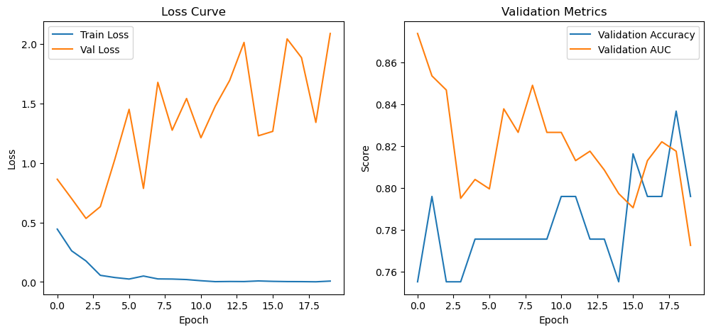

```python
plt.figure(figsize=(12,5))
plt.subplot(1,2,1)
plt.plot(train_losses, label='Train Loss')
plt.plot(val_losses, label='Val Loss')
plt.title('Loss Curve')
plt.xlabel('Epoch')
plt.ylabel('Loss')
plt.legend()

plt.subplot(1,2,2)
plt.plot(val_accuracies, label='Validation Accuracy')
plt.plot(val_aucs, label='Validation AUC')
plt.title('Validation Metrics')
plt.xlabel('Epoch')
plt.ylabel('Score')
plt.legend()

plt.show()
```

```
Final Validation Metrics:
Accuracy: 0.7959
Precision: 1.0000
Recall: 0.1667
F1 Score: 0.2857
ROC AUC: 0.7725
Confusion Matrix:
[[37  0]
 [10  2]]
```

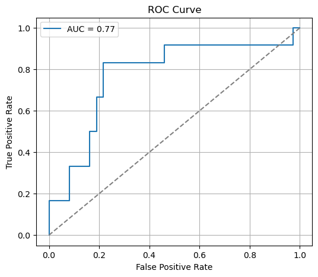

```python
# After training
model.eval()
all_labels = []
all_preds = []

with torch.no_grad():
    for left_img, right_img, clinical_data, labels in val_loader:
        left_img = left_img.to(device)
        right_img = right_img.to(device)
        clinical_data = clinical_data.to(device)
        labels = labels.to(device)
        labels = labels.unsqueeze(1)

        outputs = model(left_img, right_img, clinical_data)
        preds = torch.sigmoid(outputs)

        preds = preds.detach().cpu().numpy()
        labels = labels.detach().cpu().numpy()

        all_labels.extend(labels.flatten())
        all_preds.extend(preds.flatten())

all_labels = np.array(all_labels)
all_preds = np.array(all_preds)
binary_preds = np.round(all_preds)

acc = accuracy_score(all_labels, binary_preds)
precision = precision_score(all_labels, binary_preds)
recall = recall_score(all_labels, binary_preds)
f1 = f1_score(all_labels, binary_preds)
auc = roc_auc_score(all_labels, all_preds)
cm = confusion_matrix(all_labels, binary_preds)

print(f"\nFinal Validation Metrics:")
print(f"Accuracy: {acc:.4f}")
print(f"Precision: {precision:.4f}")
print(f"Recall: {recall:.4f}")
print(f"F1 Score: {f1:.4f}")
print(f"ROC AUC: {auc:.4f}")
print(f"Confusion Matrix:\n{cm}")

# ROC curve
fpr, tpr, thresholds = roc_curve(all_labels, all_preds)
plt.figure(figsize=(6,5))
plt.plot(fpr, tpr, label=f'AUC = {auc:.2f}')
plt.plot([0, 1], [0, 1], '--', color='gray')
plt.xlabel('False Positive Rate')
plt.ylabel('True Positive Rate')
plt.title('ROC Curve')
plt.legend()
plt.grid()
plt.show()
```

Well this didn't work out well. The ROC is worse than both of the other models so the multimodal model is running sub-optimally with an AUC of only 0.77. Recall we had 0.84 in the clinical data only model and a stellar 0.94 in the imaging model. One potential reason for this could be that the clinical data has some oddities within it. Indeed, perhaps the imputations that we performed above were incorrect and our assumptions were wrong.

So let's try the multimodal option again by just just using the relevant clinical factors. Now, we will use different classifications by incorporating the "suspected" glaucoma patients into the glaucoma group and remove factors age and gender from the model. Age and gender aren't 100% reliable in determining glaucoma disase and isn't a basis for physicians to make a final decision on disease diagnosis so we can feel comfortable removing it here. Ok so let's do all of this and re-work the model.

```python
import pandas as pd

# Load the existing metadata
df = pd.read_csv(r'C:\Users\derek\Downloads\PAPILA\PAPILA\metadata.csv')

# Fill missing Diagnoses with 0 (Non-Glaucoma)
df['Diagnosis_OD'] = df['Diagnosis_OD'].fillna(0)
df['Diagnosis_OS'] = df['Diagnosis_OS'].fillna(0)

# Redefine label: treat Diagnosis 1 or 2 as positive
df['label'] = (
    ((df['Diagnosis_OD'] == 1) | (df['Diagnosis_OD'] == 2)) |
    ((df['Diagnosis_OS'] == 1) | (df['Diagnosis_OS'] == 2))
).astype(int)

# Save the new metadata
df.to_csv(r'C:\Users\derek\Downloads\PAPILA\PAPILA\metadata_updated.csv', index=False)

# Quick check
print(df['label'].value_counts())
print("Saved metadata_updated.csv ✅")
```

```
label
0    163
1     81
Name: count, dtype: int64
Saved metadata_updated.csv ✅
```

```python
class MultimodalDataset(Dataset):
    def __init__(self, csv_file, img_size=224):
        self.data = pd.read_csv(csv_file)

        # Only select the strongest clinical features
        self.clinical_features = [
            'Pachymetry_OD', 'Pachymetry_OS',
            'Axial_Length_OD', 'Axial_Length_OS',
            'Pneumatic_OD', 'Pneumatic_OS',
            'Perkins_OD', 'Perkins_OS',
            'VF_MD_OD', 'VF_MD_OS'
        ]

        self.transform = transforms.Compose([
            transforms.Resize((img_size, img_size)),
            transforms.ToTensor(),
            transforms.Normalize([0.5], [0.5])
        ])

    def __len__(self):
        return len(self.data)

    def __getitem__(self, idx):
        row = self.data.iloc[idx]

        left_img = Image.open(row['left_eye_image_path']).convert('RGB')
        right_img = Image.open(row['right_eye_image_path']).convert('RGB')

        left_img = self.transform(left_img)
        right_img = self.transform(right_img)

        clinical = torch.tensor(row[self.clinical_features].astype(np.float32).values, dtype=torch.float32)
        label = torch.tensor(row['label'], dtype=torch.float32)

        return left_img, right_img, clinical, label
```

```python
csv_file = r'C:\Users\derek\Downloads\PAPILA\PAPILA\metadata_updated.csv'

full_dataset = MultimodalDataset(csv_file)
train_size = int(0.8 * len(full_dataset))
val_size = len(full_dataset) - train_size

train_dataset, val_dataset = random_split(full_dataset, [train_size, val_size])

train_loader = DataLoader(train_dataset, batch_size=16, shuffle=True)
val_loader = DataLoader(val_dataset, batch_size=16, shuffle=False)

num_clinical_features = len(full_dataset.clinical_features)
model = MultimodalGlaucomaModel(num_clinical_features=num_clinical_features).to(device)

criterion = nn.BCEWithLogitsLoss()
optimizer = optim.Adam(model.parameters(), lr=1e-4)
```

```python
train_losses = []
val_losses = []
val_accuracies = []
val_aucs = []

for epoch in range(num_epochs):
    model.train()
    running_loss = 0.0

    for left_img, right_img, clinical_data, labels in train_loader:
        left_img = left_img.to(device)
        right_img = right_img.to(device)
        clinical_data = clinical_data.to(device)
        labels = labels.to(device)
        labels = labels.unsqueeze(1)  # (batch_size, 1)

        optimizer.zero_grad()
        outputs = model(left_img, right_img, clinical_data)

        loss = criterion(outputs, labels)
        loss.backward()
        optimizer.step()

        running_loss += loss.item()

    avg_train_loss = running_loss / len(train_loader)
    train_losses.append(avg_train_loss)

    # Validation
    model.eval()
    val_loss = 0.0
    all_labels = []
    all_preds = []

    with torch.no_grad():
        for left_img, right_img, clinical_data, labels in val_loader:
            left_img = left_img.to(device)
            right_img = right_img.to(device)
            clinical_data = clinical_data.to(device)
            labels = labels.to(device)
            labels = labels.unsqueeze(1)

            outputs = model(left_img, right_img, clinical_data)
            loss = criterion(outputs, labels)
            val_loss += loss.item()

            preds = torch.sigmoid(outputs)
            preds = preds.detach().cpu().numpy()
            labels = labels.detach().cpu().numpy()

            all_labels.extend(labels.flatten())
            all_preds.extend(preds.flatten())

    avg_val_loss = val_loss / len(val_loader)
    val_losses.append(avg_val_loss)

    val_acc = accuracy_score(np.round(all_labels), np.round(all_preds))
    val_auc = roc_auc_score(all_labels, all_preds)

    val_accuracies.append(val_acc)
    val_aucs.append(val_auc)

    print(f"Epoch [{epoch+1}/{num_epochs}] "
          f"Train Loss: {avg_train_loss:.4f} "
          f"Val Loss: {avg_val_loss:.4f} "
          f"Val Acc: {val_acc:.4f} "
          f"Val AUC: {val_auc:.4f}")
```

```
Epoch [1/20] Train Loss: 0.6781 Val Loss: 0.5052 Val Acc: 0.7755 Val AUC: 0.8868
Epoch [2/20] Train Loss: 0.3686 Val Loss: 0.4260 Val Acc: 0.8163 Val AUC: 0.8675
Epoch [3/20] Train Loss: 0.2857 Val Loss: 0.7663 Val Acc: 0.7755 Val AUC: 0.8291
Epoch [4/20] Train Loss: 0.1976 Val Loss: 0.7045 Val Acc: 0.7551 Val AUC: 0.7927
Epoch [5/20] Train Loss: 0.0973 Val Loss: 0.5987 Val Acc: 0.8163 Val AUC: 0.8462
Epoch [6/20] Train Loss: 0.0591 Val Loss: 0.4945 Val Acc: 0.7959 Val AUC: 0.8205
Epoch [7/20] Train Loss: 0.0549 Val Loss: 0.5013 Val Acc: 0.7959 Val AUC: 0.7970
Epoch [8/20] Train Loss: 0.0912 Val Loss: 0.4238 Val Acc: 0.7959 Val AUC: 0.8440
Epoch [9/20] Train Loss: 0.0597 Val Loss: 0.5948 Val Acc: 0.8163 Val AUC: 0.7906
Epoch [10/20] Train Loss: 0.0571 Val Loss: 0.3999 Val Acc: 0.8367 Val AUC: 0.8697
Epoch [11/20] Train Loss: 0.0342 Val Loss: 0.6413 Val Acc: 0.8163 Val AUC: 0.8034
Epoch [12/20] Train Loss: 0.0202 Val Loss: 0.7553 Val Acc: 0.8367 Val AUC: 0.7735
Epoch [13/20] Train Loss: 0.0570 Val Loss: 0.5272 Val Acc: 0.7959 Val AUC: 0.8184
Epoch [14/20] Train Loss: 0.1259 Val Loss: 0.7013 Val Acc: 0.7551 Val AUC: 0.7970
Epoch [15/20] Train Loss: 0.0646 Val Loss: 0.3535 Val Acc: 0.8571 Val AUC: 0.8504
Epoch [16/20] Train Loss: 0.0278 Val Loss: 0.3808 Val Acc: 0.8980 Val AUC: 0.8590
Epoch [17/20] Train Loss: 0.2362 Val Loss: 0.4182 Val Acc: 0.8163 Val AUC: 0.8419
Epoch [18/20] Train Loss: 0.2130 Val Loss: 0.5856 Val Acc: 0.7755 Val AUC: 0.8739
Epoch [19/20] Train Loss: 0.1378 Val Loss: 0.6478 Val Acc: 0.7959 Val AUC: 0.7799
Epoch [20/20] Train Loss: 0.1182 Val Loss: 0.5164 Val Acc: 0.7959 Val AUC: 0.8056
```

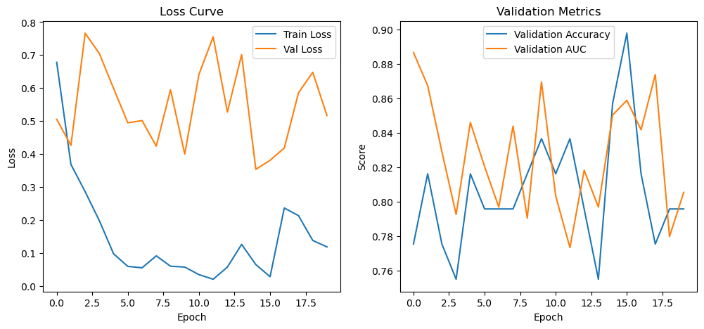

```python
plt.figure(figsize=(12,5))
plt.subplot(1,2,1)
plt.plot(train_losses, label='Train Loss')
plt.plot(val_losses, label='Val Loss')
plt.title('Loss Curve')
plt.xlabel('Epoch')
plt.ylabel('Loss')
plt.legend()

plt.subplot(1,2,2)
plt.plot(val_accuracies, label='Validation Accuracy')
plt.plot(val_aucs, label='Validation AUC')
plt.title('Validation Metrics')
plt.xlabel('Epoch')
plt.ylabel('Score')
plt.legend()

plt.show()
```

```
Final Validation Metrics:
Accuracy: 0.7959
Precision: 0.6364
Recall: 0.5385
F1 Score: 0.5833
ROC AUC: 0.8056
Confusion Matrix:
[[32  4]
 [ 6  7]]
```

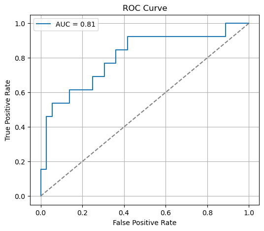

```python
# After training
model.eval()
all_labels = []
all_preds = []

with torch.no_grad():
    for left_img, right_img, clinical_data, labels in val_loader:
        left_img = left_img.to(device)
        right_img = right_img.to(device)
        clinical_data = clinical_data.to(device)
        labels = labels.to(device)
        labels = labels.unsqueeze(1)

        outputs = model(left_img, right_img, clinical_data)
        preds = torch.sigmoid(outputs)

        preds = preds.detach().cpu().numpy()
        labels = labels.detach().cpu().numpy()

        all_labels.extend(labels.flatten())
        all_preds.extend(preds.flatten())

all_labels = np.array(all_labels)
all_preds = np.array(all_preds)
binary_preds = np.round(all_preds)

acc = accuracy_score(all_labels, binary_preds)
precision = precision_score(all_labels, binary_preds)
recall = recall_score(all_labels, binary_preds)
f1 = f1_score(all_labels, binary_preds)
auc = roc_auc_score(all_labels, all_preds)
cm = confusion_matrix(all_labels, binary_preds)

print(f"\nFinal Validation Metrics:")
print(f"Accuracy: {acc:.4f}")
print(f"Precision: {precision:.4f}")
print(f"Recall: {recall:.4f}")
print(f"F1 Score: {f1:.4f}")
print(f"ROC AUC: {auc:.4f}")
print(f"Confusion Matrix:\n{cm}")

# ROC curve
fpr, tpr, thresholds = roc_curve(all_labels, all_preds)
plt.figure(figsize=(6,5))
plt.plot(fpr, tpr, label=f'AUC = {auc:.2f}')
plt.plot([0, 1], [0, 1], '--', color='gray')
plt.xlabel('False Positive Rate')
plt.ylabel('True Positive Rate')
plt.title('ROC Curve')
plt.legend()
plt.grid()
plt.show()
```

Well we did some improvment since the AUC went from 0.77 to 0.81. It's not quite at the level of the other models however and not a huge disappointment, but it's not something that we would want to impelement on a wide scale just yet.

## Conclusions

We have developed 3 different models here based on the data at hand. We deveveloped a multilayered perceptron on the clincial data, a convolutional neural network on the imaging data, and a fusion model taking both of the data sources.

In terms of AUC, the imaging study did the best followed by the clinical only model and finally the fusion model performed the worst. The AUC for imaging was 0.94, clinical data only 0.84, and fusion was 0.81. I think the real take home message here is that there is no single model that comes up with something that we can confidently put inside a clinic yet for diagnostics.

Further directions, get MORE MORE MORE data. We are severely limited here by the amount of data that we have in just a couple of hundred patients. There are larger datasets out there, but they are not for public use yet.

Try different more complicated models. We could try to use some ensemble methods instead of just a simple fusion of features. By doing this we can weight the data differently. One of the considerations of our model is that we treat clinical data and imaging the same. We might want to redo the model with a heavy weight placed on the imaging and using the clinical data with a reduced impact.

Overall, there are many directions to take this type of multimodal approach. A multimodal approach might be beneficial to cancer diagnosis combining tissue pathology with biomaker data, or Alzheimer's diagnosis combining MRI with cognitive testing. Here we are trying to use clinical features with imaging which seems to be a bit lacking. However, the models do perform well overall and are in line with publicly available models.